# Midterm

Qijia Liu

2022-02-13

## Midterm (Due Sunday 2/13/2022 at 11:55 pm)

Please submit your `.Rmd` and `.html` files in Sakai. If you are working together, both people should submit the files.

## 60 / 60 points total

The goal of the midterm project is to showcase skills that you have learned in class so far. The midterm is open note, but if you use someone else’s code, you **must attribute them**.

## Instructions: Before you get Started

1. Pick a dataset. Ideally, the dataset should be around 2000 rows, and should have both categorical and numeric covariates. Choose a dataset with more than 4 columns/variables.
- Potential Sources for data: Tidy Tuesday: https://github.com/rfordatascience/tidytuesday.
- See other data sources in the `#data` channel on Slack.
- Note that most of the Tidy Tuesday data are .csv files. There is code to load the files from csv for each of the datasets and a short description of the variables, or you can upload the `.csv` file into your `data` folder.
- You may use another dataset or your own data, but please make sure it is de-identified.
2. Define a research question, involving at least one categorical variable. You may schedule a time with Jessica or Colin to discuss your dataset and research question, or you may message it to one of us in slack or email. Please do one of the two options pretty early on. We just want to look at the data and make sure that it is appropriate for your question.
3. You must use each of the following functions at least once:
- `mutate()`
- `group_by()`
- `summarize()`
- `ggplot()`

and *at least one* of the following:

- `case_when()`
- `across()`
- `*_join()` (i.e. `left_join()`)
- `pivot_*()` (i.e. `pivot_longer()`)
4. The code chunks below are guides, please add more code chunks to do what you need.
5. If you do not want your final project posted on the public website, please let Jessica know. We can also keep it anonymous if you’d like to remove your name from the Rmd and html, or use a pseudonym.

*You may remove these instructions from your final Rmd if you like*

## Working Together

If you’d like to work together, that is encouraged, but you must divide the work equitably and you must note who worked on what. This is probably easiest as notes in the text. Please let Colin or Jessica know that you’ll be working together.

No acknowledgements of contributions = -10 points overall.

## Please Note

I will take off points (-5 points for each section) if you don’t add observations and notes in your RMarkdown document. I want you to think and reason through your analysis, even if they are preliminary thoughts.

## Define Your Research Question (10 points)

> *Define your research question below. What about the data interests you? What is a specific question you want to find out about the data?*

I am a chocolate lover and I enjoy all types of chocolate. Luckily I found the chocolatebar dataset from TidyTuesday on GitHub website so I could dedicate this project to chocolate. I’ve used this dataset for my function of the week, and I’d like to keep exploring this dataset in the midterm project.  
The specific questions that I’m interested in is to see if there is a correlation between percentage of cocoa and the rating of the chocolate, and if adding different numbers of ingredients would correlate with the rating score as well. I also want to know where the most popular beans are among the countries of origin and who the company manufacturers are with relatively high rating.

> *Given your question, what is your expectation about the data?*

Intuitively, customers do not like the chocolate with high cocoa percentage. More ingredients can maximize chocolate’s flavor, therefore the chocolate bars with more ingredients probably have better reviews scores. I’m expecting the most popular beans come from the countries where located in the southern hemisphere. I’ve never heard of the chocolate manufacturers in this datasets, so I’d like to know which of them have the best reviews.

## Loading the Data (10 points)

> *Load the data below and use `dplyr::glimpse()` or `skimr::skim()` on the data. You should upload the data file into the `data` directory.*

```r
#tuesdata <- tt_load('2022-01-18')
#ChocolateBar <-  tuesdata$chocolate

ChocolateBar <- readr::read_csv('https://raw.githubusercontent.com/rfordatascience/tidytuesday/master/data/2022/2022-01-18/chocolate.csv')

glimpse(ChocolateBar)
```

```
## Rows: 2,530
## Columns: 10
## $ ref                              <dbl> 2454, 2458, 2454, 2542, 2546, 2546, 2~
## $ company_manufacturer             <chr> "5150", "5150", "5150", "5150", "5150~
## $ company_location                 <chr> "U.S.A.", "U.S.A.", "U.S.A.", "U.S.A.~
## $ review_date                      <dbl> 2019, 2019, 2019, 2021, 2021, 2021, 2~
## $ country_of_bean_origin           <chr> "Tanzania", "Dominican Republic", "Ma~
## $ specific_bean_origin_or_bar_name <chr> "Kokoa Kamili, batch 1", "Zorzal, bat~
## $ cocoa_percent                    <chr> "76%", "76%", "76%", "68%", "72%", "8~
## $ ingredients                      <chr> "3- B,S,C", "3- B,S,C", "3- B,S,C", "~
## $ most_memorable_characteristics   <chr> "rich cocoa, fatty, bready", "cocoa, ~
## $ rating                           <dbl> 3.25, 3.50, 3.75, 3.00, 3.00, 3.25, 3~
```

```r
# Check all data frame columns and get a sum of NA values in them
cbind(lapply(lapply(ChocolateBar, is.na), sum))
```

```
##                                  [,1]
## ref                              0
## company_manufacturer             0
## company_location                 0
## review_date                      0
## country_of_bean_origin           0
## specific_bean_origin_or_bar_name 0
## cocoa_percent                    0
## ingredients                      87
## most_memorable_characteristics   0
## rating                           0
```

> *If there are any quirks that you have to deal with `NA` coded as something else, or it is multiple tables, please make some notes here about what you need to do before you start transforming the data in the next section.*

> **Make sure your data types are correct!**

After I had an general idea of the dataset, I made a list about what I wanted to do in the next step, transforming the data:

- Remove the variables which are not relative to my research questions: ref, company_location, review_date, specific_bean_origin_or_bar_name, and most_memorable_characteristics.
- Remove % sign for cocoa_percent variable, and then convert it into numeric variable.
- Separate ingredients variable and only keep the number of ingredients in the chocolate, delete the information of the types of ingredients. Then convert it into factor variable(for model building purpose).
- For 87 missing values “NA” in character variable ingredients, I will remove them from my dataset in the next section.

## Transforming the data (15 points)

> *If the data needs to be transformed in any way (values recoded, pivoted, etc), do it here. Examples include transforming a continuous variable into a categorical using `case_when()`, etc.*

```r
# Remove the variables that not needed
ChocolateBar <- ChocolateBar %>%
  select(-ref, -company_location, -review_date, -specific_bean_origin_or_bar_name, -most_memorable_characteristics)


# Remove % sign
ChocolateBar <- ChocolateBar %>%
  mutate(cocoa_percent = as.numeric(gsub("%", "", cocoa_percent)))


# Separate ingredients variable
ChocolateBar <- ChocolateBar %>%
  separate(
    col = ingredients,
    into = c("ingredients", "type"),
    sep = "-") %>%
  mutate(ingredients = na_if(ingredients, "NA"),
         type = na_if(type, "NA")) %>%
  select(-type) %>%
  mutate(ingredients = as.factor(ingredients)) %>%
  drop_na()
```

> *Bonus points (5 points) for datasets that require merging of tables, but only if you reason through whether you should use `left_join`, `inner_join`, or `right_join` on these tables. No credit will be provided if you don’t.*

> *Show your transformed table here.* Use tools such as `glimpse()`, `skim()` or `head()` to illustrate your point.

```r
skim(ChocolateBar)
```

Data summary

| Name | ChocolateBar |
| --- | --- |
| Number of rows | 2443 |
| Number of columns | 5 |
| _______________________ |  |
| Column type frequency: |  |
| character | 2 |
| factor | 1 |
| numeric | 2 |
| ________________________ |  |
| Group variables | None |

**Variable type: character**

| skim_variable | n_missing | complete_rate | min | max | empty | n_unique | whitespace |
| --- | --- | --- | --- | --- | --- | --- | --- |
| company_manufacturer | 0 | 1 | 2 | 39 | 0 | 542 | 0 |
| country_of_bean_origin | 0 | 1 | 4 | 21 | 0 | 62 | 0 |

**Variable type: factor**

| skim_variable | n_missing | complete_rate | ordered | n_unique | top_counts |
| --- | --- | --- | --- | --- | --- |
| ingredients | 0 | 1 | FALSE | 6 | 3: 1023, 2: 750, 4: 469, 5: 191 |

**Variable type: numeric**

| skim_variable | n_missing | complete_rate | mean | sd | p0 | p25 | p50 | p75 | p100 | hist |
| --- | --- | --- | --- | --- | --- | --- | --- | --- | --- | --- |
| cocoa_percent | 0 | 1 | 71.50 | 5.16 | 42 | 70 | 70.00 | 74.0 | 100 | ▁▁▇▁▁ |
| rating | 0 | 1 | 3.21 | 0.43 | 1 | 3 | 3.25 | 3.5 | 4 | ▁▁▅▇▇ |

> *Are the values what you expected for the variables? Why or Why not?*

After transformed my variables as I planed, I got two character variables(company_manufacturer and country_of_bean_origin), two numeric variables (cocoa_percent and rating) and one factor variable(ingredients). They are the variables with right formats as I expected, and I’m going to use them for answering my research questions.

## Visualizing and Summarizing the Data (15 points)

> *Use `group_by()` and `summarize()` to make a summary of the data here. The summary should be relevant to your research question*

> *Make at least two plots that help you answer your question on the transformed or summarized data. Use scales and/or labels to make each plot informative.*

```r
ChocolateBar %>%
  summarise(across(where(is.character), n_distinct))
```

```
## # A tibble: 1 x 2
##   company_manufacturer country_of_bean_origin
##                  <int>                  <int>
## 1                  542                     62
```

```r
# country_of_bean_origin
ChocolateBar %>%
  tabyl(country_of_bean_origin) %>%
  arrange(desc(n)) %>%
  top_frac(.25) %>%
  gt()
```

| country_of_bean_origin | n | percent |
| --- | --- | --- |
| Venezuela | 246 | 0.10069587 |
| Peru | 231 | 0.09455587 |
| Dominican Republic | 220 | 0.09005321 |
| Ecuador | 201 | 0.08227589 |
| Madagascar | 171 | 0.06999591 |
| Blend | 144 | 0.05894392 |
| Nicaragua | 100 | 0.04093328 |
| Bolivia | 79 | 0.03233729 |
| Colombia | 78 | 0.03192796 |
| Tanzania | 78 | 0.03192796 |
| Brazil | 77 | 0.03151862 |
| Belize | 74 | 0.03029063 |
| Vietnam | 73 | 0.02988129 |
| Guatemala | 62 | 0.02537863 |
| Mexico | 54 | 0.02210397 |

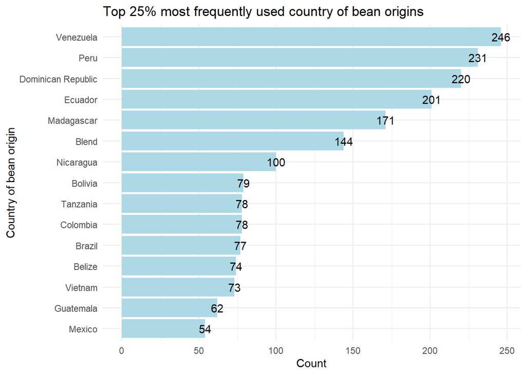

```r
ChocolateBar %>%
  group_by(country_of_bean_origin) %>%
  filter(n() >= 54) %>%
  mutate(count = n()) %>%
  ggplot(aes(x = reorder(country_of_bean_origin, count))) +
  geom_bar(fill="lightblue") +
  coord_flip() +
  geom_text(stat = "count",aes(label = ..count..)) +
  labs(x = 'Country of bean origin', y = 'Count', title = 'Top 25% most frequently used country of bean origins') +
  theme_minimal()
```

```r
# company_manufacturer
ChocolateBar %>%
  tabyl(company_manufacturer) %>%
  arrange(desc(n)) %>%
  top_frac(.05) %>%
  gt()
```

| company_manufacturer | n | percent |
| --- | --- | --- |
| Soma | 56 | 0.022922636 |
| Fresco | 39 | 0.015963979 |
| Arete | 32 | 0.013098649 |
| Bonnat | 29 | 0.011870651 |
| A. Morin | 26 | 0.010642652 |
| Dandelion | 25 | 0.010233320 |
| Pralus | 25 | 0.010233320 |
| Domori | 22 | 0.009005321 |
| Guittard | 22 | 0.009005321 |
| Valrhona | 22 | 0.009005321 |
| Zotter | 21 | 0.008595989 |
| Castronovo | 19 | 0.007777323 |
| Dick Taylor | 19 | 0.007777323 |
| Coppeneur | 18 | 0.007367990 |
| Mast Brothers | 18 | 0.007367990 |
| Duffy's | 17 | 0.006958657 |
| Pierre Marcolini | 17 | 0.006958657 |
| Scharffen Berger | 17 | 0.006958657 |
| Smooth Chocolator, The | 17 | 0.006958657 |
| Rogue | 16 | 0.006549325 |
| Artisan du Chocolat | 15 | 0.006139992 |
| Letterpress | 15 | 0.006139992 |
| Palette de Bine | 15 | 0.006139992 |
| Szanto Tibor | 15 | 0.006139992 |
| Bittersweet Origins | 14 | 0.005730659 |
| Fruition | 14 | 0.005730659 |
| Hotel Chocolat (Coppeneur) | 14 | 0.005730659 |
| Map Chocolate | 14 | 0.005730659 |
| Sirene | 14 | 0.005730659 |
| Tejas | 14 | 0.005730659 |

```r
ChocolateBar %>%
  group_by(company_manufacturer) %>%
  filter(n() >= 14) %>%
  summarize(mean_rating = mean(rating)) %>%
  arrange(desc(mean_rating)) %>%
  gt()
```

| company_manufacturer | mean_rating |
| --- | --- |
| Soma | 3.589286 |
| Bonnat | 3.534483 |
| Arete | 3.531250 |
| Domori | 3.522727 |
| Smooth Chocolator, The | 3.514706 |
| Dick Taylor | 3.486842 |
| Duffy's | 3.441176 |
| Letterpress | 3.433333 |
| Fruition | 3.428571 |
| A. Morin | 3.423077 |
| Rogue | 3.421875 |
| Fresco | 3.416667 |
| Szanto Tibor | 3.400000 |
| Pierre Marcolini | 3.397059 |
| Sirene | 3.392857 |
| Castronovo | 3.381579 |
| Zotter | 3.321429 |
| Valrhona | 3.318182 |
| Dandelion | 3.300000 |
| Bittersweet Origins | 3.267857 |
| Coppeneur | 3.250000 |
| Map Chocolate | 3.250000 |
| Palette de Bine | 3.233333 |
| Scharffen Berger | 3.220588 |
| Pralus | 3.180000 |
| Guittard | 3.170455 |
| Artisan du Chocolat | 3.166667 |
| Mast Brothers | 3.125000 |
| Hotel Chocolat (Coppeneur) | 3.053571 |
| Tejas | 3.017857 |

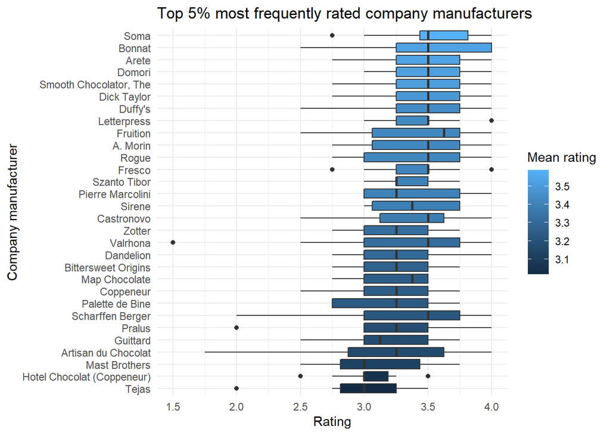

```r
ChocolateBar %>%
  group_by(company_manufacturer) %>%
  filter(n() >= 14) %>%
  mutate(mean_rating = mean(rating)) %>%
  ggplot(aes(reorder(company_manufacturer, mean_rating), rating, fill = mean_rating)) +
  geom_boxplot() +
  coord_flip()  +
  labs(x = 'Company manufacturer', y = 'Rating', title = 'Top 5% most frequently rated company manufacturers') +
  scale_fill_continuous(name = "Mean rating") +
  theme_minimal()
```

> *What are your findings about the summary? Are they what you expected?*

```r
ChocolateBar %>%
  tabyl(ingredients) %>%
  gt()
```

| ingredients | n | percent |
| --- | --- | --- |
| 1 | 6 | 0.002455997 |
| 2 | 750 | 0.306999591 |
| 3 | 1023 | 0.418747442 |
| 4 | 469 | 0.191977077 |
| 5 | 191 | 0.078182562 |
| 6 | 4 | 0.001637331 |

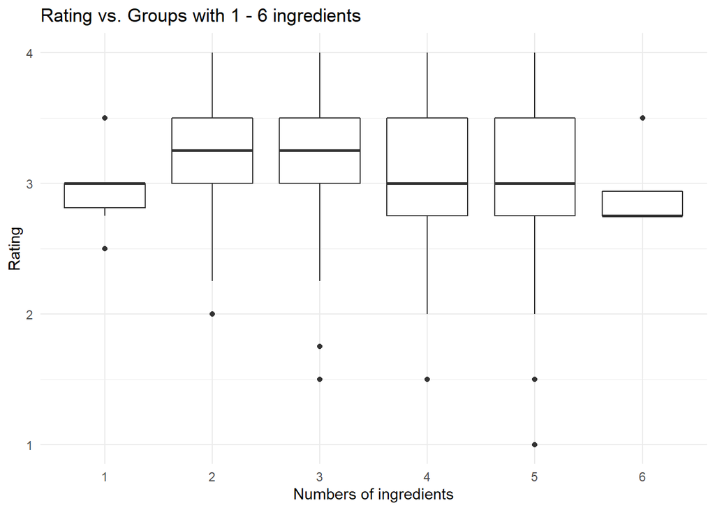

```r
# numbers of ingredients vs. the rating of the chocolate
ChocolateBar %>%
  group_by(ingredients) %>%
  ggplot(aes(x = ingredients, y = rating)) +
  geom_boxplot() +
  labs(title = "Rating vs. Groups with 1 - 6 ingredients", x = 'Numbers of ingredients', y = 'Rating') +
  theme_minimal()
```

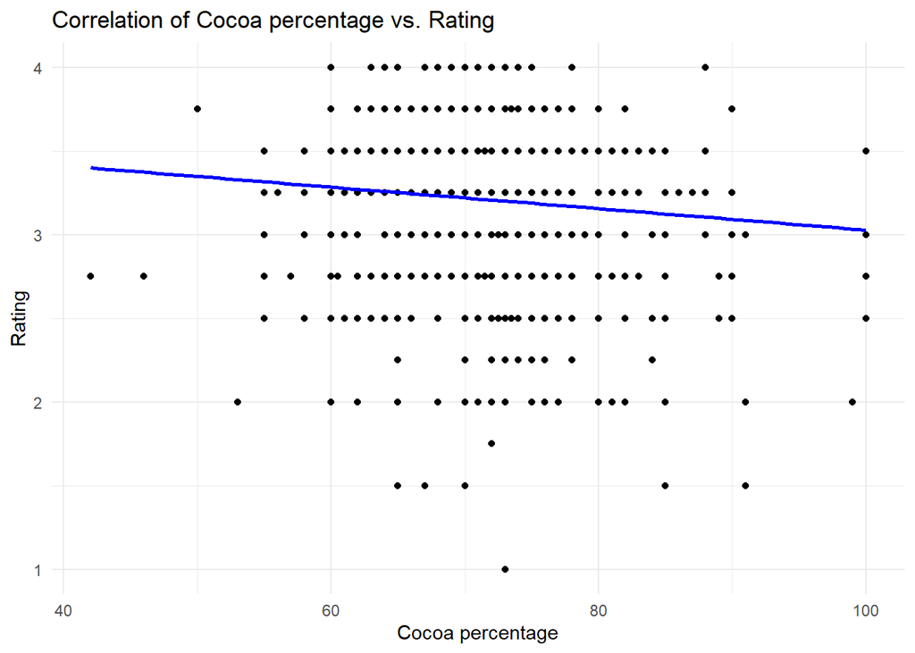

```r
# percentage of cocoa vs. the rating of the chocolate
ChocolateBar %>%
  ggplot(aes(x = cocoa_percent, y = rating)) +
  geom_point() +
  geom_smooth(method = 'lm', se = FALSE, col = 'blue') +
  labs(title = "Correlation of Cocoa percentage vs. Rating", x = 'Cocoa percentage', y = 'Rating') +
  theme_minimal()
```

> *What are your findings about the summary?*

Three ingredients in chocolate appears the highest frequency. The above boxplot also shows that the distribution of rating values is different among the six levels of ingredients. Two and three ingredients have the highest median value while six ingredients has a lowest median value. In the second scatter plot, with increasing of cocoa percentage, the rating of chocolate bar slightly decreases.

```r
# linear regression model
model <- lm(rating ~ cocoa_percent, data = ChocolateBar)
summary(model)
```

```
##
## Call:
## lm(formula = rating ~ cocoa_percent, data = ChocolateBar)
##
## Residuals:
##      Min       1Q   Median       3Q      Max
## -2.20045 -0.21968  0.03032  0.28673  0.89570
##
## Coefficients:
##                Estimate Std. Error t value Pr(>|t|)
## (Intercept)    3.668419   0.120159  30.530  < 2e-16 ***
## cocoa_percent -0.006410   0.001676  -3.824 0.000134 ***
## ---
## Signif. codes:  0 '***' 0.001 '**' 0.01 '*' 0.05 '.' 0.1 ' ' 1
##
## Residual standard error: 0.4272 on 2441 degrees of freedom
## Multiple R-squared:  0.005956,   Adjusted R-squared:  0.005548
## F-statistic: 14.63 on 1 and 2441 DF,  p-value: 0.0001344
```

```r
model <- lm(rating ~ cocoa_percent + ingredients, data = ChocolateBar)
summary(model)
```

```
##
## Call:
## lm(formula = rating ~ cocoa_percent + ingredients, data = ChocolateBar)
##
## Residuals:
##      Min       1Q   Median       3Q      Max
## -2.04543 -0.28104  0.00846  0.27519  0.94620
##
## Coefficients:
##                Estimate Std. Error t value Pr(>|t|)
## (Intercept)    3.795007   0.245475  15.460  < 2e-16 ***
## cocoa_percent -0.008367   0.001749  -4.782 1.84e-06 ***
## ingredients2   0.026235   0.179641   0.146    0.884
## ingredients3   0.074040   0.179637   0.412    0.680
## ingredients4  -0.075624   0.180720  -0.418    0.676
## ingredients5  -0.138801   0.183154  -0.758    0.449
## ingredients6  -0.250919   0.276482  -0.908    0.364
## ---
## Signif. codes:  0 '***' 0.001 '**' 0.01 '*' 0.05 '.' 0.1 ' ' 1
##
## Residual standard error: 0.4218 on 2436 degrees of freedom
## Multiple R-squared:  0.03287,    Adjusted R-squared:  0.03048
## F-statistic:  13.8 on 6 and 2436 DF,  p-value: 1.772e-15
```

> *What are your findings about the summary?*

## Final Summary (10 points)

> *Summarize your research question and findings below.*

In summary, regardless of the R-squared value, there is a significant relationship between cocoa percentage and the rating of the chocolate bar. Although ingredients could help to explain some of the variation in the rating variable around its mean, a statistically significant relationship is not found between ingredients and the rating scores. To further explore, to my way of thinking, we might need to include more variable in the model for a better prediction. The top three most popular beans are from Venezuela, Peru and Dominican Republic. The highest frequently rated with the highest rating score company manufacturers are Soma, Bonnat and Arete.

> *Are your findings what you expected? Why or Why not?*

The findings generally meet my expectation. The linear regression models shows the evidence that cocoa percentage is significantly correlated to the rating score. But non of the level of ingredients was significantly correlated with the rating, which is a bit unexpected for me. Cacao trees must grow in a limited geographical zone, with hotter tropical climates and lower elevations. Hence, the top three of most frequently used country of bean origins: Venezuela, Peru and Dominican Republic, are all the habitat which meet the growing requirement. For the highest rating score company manufacturers, I googled their names and found their information on the website of Academy of Chocolate. I also tried to find the individual manufacturers information, for instance, Soma, it is a small chocolate factory which start their business in 2003, and Bonnat is a French chocolate maker. It makes sense to me that why I am not familiar with their company manufacturers names. The reasons could be they are foreign brands, small factory or establishing their brand very late.